# Risk Factor Analysis

## Outcome Variable

**Outcome Variable:** ever_wasted

## Predictor Variables

**Intervention Variable:** hhwealth_quart

**Adjustment Set:**

- arm
- sex
- W_mage
- meducyrs
- feducyrs
- W_gagebrth
- W_birthwt
- W_birthlen
- W_nchldlt5
- W_parity
- delta_W_mage
- delta_meducyrs
- delta_feducyrs
- delta_W_gagebrth
- delta_W_birthwt
- delta_W_birthlen
- delta_W_nchldlt5
- delta_W_parity

## Stratifying Variables

The analysis was stratified on these variable(s):

- agecat
- studyid
- country

## Data Summary

| agecat | studyid | country | hhwealth_quart | ever_wasted | n_cell | n |
| --- | --- | --- | --- | --- | --- | --- |
| 0-24 months | CMC-V-BCS-2002 | INDIA | Wealth Q4 | 0 | 44 | 373 |
| 0-24 months | CMC-V-BCS-2002 | INDIA | Wealth Q4 | 1 | 52 | 373 |
| 0-24 months | CMC-V-BCS-2002 | INDIA | Wealth Q1 | 0 | 37 | 373 |
| 0-24 months | CMC-V-BCS-2002 | INDIA | Wealth Q1 | 1 | 54 | 373 |
| 0-24 months | CMC-V-BCS-2002 | INDIA | Wealth Q2 | 0 | 26 | 373 |
| 0-24 months | CMC-V-BCS-2002 | INDIA | Wealth Q2 | 1 | 69 | 373 |
| 0-24 months | CMC-V-BCS-2002 | INDIA | Wealth Q3 | 0 | 38 | 373 |
| 0-24 months | CMC-V-BCS-2002 | INDIA | Wealth Q3 | 1 | 53 | 373 |
| 0-24 months | COHORTS | GUATEMALA | Wealth Q4 | 0 | 366 | 1263 |
| 0-24 months | COHORTS | GUATEMALA | Wealth Q4 | 1 | 110 | 1263 |
| 0-24 months | COHORTS | GUATEMALA | Wealth Q1 | 0 | 166 | 1263 |
| 0-24 months | COHORTS | GUATEMALA | Wealth Q1 | 1 | 78 | 1263 |
| 0-24 months | COHORTS | GUATEMALA | Wealth Q2 | 0 | 190 | 1263 |
| 0-24 months | COHORTS | GUATEMALA | Wealth Q2 | 1 | 68 | 1263 |
| 0-24 months | COHORTS | GUATEMALA | Wealth Q3 | 0 | 211 | 1263 |
| 0-24 months | COHORTS | GUATEMALA | Wealth Q3 | 1 | 74 | 1263 |
| 0-24 months | COHORTS | PHILIPPINES | Wealth Q4 | 0 | 531 | 3044 |
| 0-24 months | COHORTS | PHILIPPINES | Wealth Q4 | 1 | 309 | 3044 |
| 0-24 months | COHORTS | PHILIPPINES | Wealth Q1 | 0 | 372 | 3044 |
| 0-24 months | COHORTS | PHILIPPINES | Wealth Q1 | 1 | 309 | 3044 |
| 0-24 months | COHORTS | PHILIPPINES | Wealth Q2 | 0 | 330 | 3044 |
| 0-24 months | COHORTS | PHILIPPINES | Wealth Q2 | 1 | 210 | 3044 |
| 0-24 months | COHORTS | PHILIPPINES | Wealth Q3 | 0 | 582 | 3044 |
| 0-24 months | COHORTS | PHILIPPINES | Wealth Q3 | 1 | 401 | 3044 |
| 0-24 months | CONTENT | PERU | Wealth Q4 | 0 | 50 | 215 |
| 0-24 months | CONTENT | PERU | Wealth Q4 | 1 | 2 | 215 |
| 0-24 months | CONTENT | PERU | Wealth Q1 | 0 | 58 | 215 |
| 0-24 months | CONTENT | PERU | Wealth Q1 | 1 | 1 | 215 |
| 0-24 months | CONTENT | PERU | Wealth Q2 | 0 | 50 | 215 |
| 0-24 months | CONTENT | PERU | Wealth Q2 | 1 | 2 | 215 |

[output cut: 402 more lines]

The following strata were considered:

- agecat: 0-24 months, studyid: CMC-V-BCS-2002, country: INDIA
- agecat: 0-24 months, studyid: COHORTS, country: GUATEMALA
- agecat: 0-24 months, studyid: COHORTS, country: PHILIPPINES
- agecat: 0-24 months, studyid: CONTENT, country: PERU
- agecat: 0-24 months, studyid: GMS-Nepal, country: NEPAL
- agecat: 0-24 months, studyid: IRC, country: INDIA
- agecat: 0-24 months, studyid: JiVitA-3, country: BANGLADESH
- agecat: 0-24 months, studyid: JiVitA-4, country: BANGLADESH
- agecat: 0-24 months, studyid: LCNI-5, country: MALAWI
- agecat: 0-24 months, studyid: MAL-ED, country: BANGLADESH
- agecat: 0-24 months, studyid: MAL-ED, country: BRAZIL
- agecat: 0-24 months, studyid: MAL-ED, country: INDIA
- agecat: 0-24 months, studyid: MAL-ED, country: NEPAL
- agecat: 0-24 months, studyid: MAL-ED, country: PERU
- agecat: 0-24 months, studyid: MAL-ED, country: SOUTH AFRICA
- agecat: 0-24 months, studyid: MAL-ED, country: TANZANIA, UNITED REPUBLIC OF
- agecat: 0-24 months, studyid: PROVIDE, country: BANGLADESH
- agecat: 0-24 months, studyid: TanzaniaChild2, country: TANZANIA, UNITED REPUBLIC OF
- agecat: 0-6 months, studyid: CMC-V-BCS-2002, country: INDIA
- agecat: 0-6 months, studyid: COHORTS, country: GUATEMALA
- agecat: 0-6 months, studyid: COHORTS, country: PHILIPPINES
- agecat: 0-6 months, studyid: CONTENT, country: PERU
- agecat: 0-6 months, studyid: GMS-Nepal, country: NEPAL
- agecat: 0-6 months, studyid: IRC, country: INDIA
- agecat: 0-6 months, studyid: JiVitA-3, country: BANGLADESH
- agecat: 0-6 months, studyid: JiVitA-4, country: BANGLADESH
- agecat: 0-6 months, studyid: LCNI-5, country: MALAWI
- agecat: 0-6 months, studyid: MAL-ED, country: BANGLADESH
- agecat: 0-6 months, studyid: MAL-ED, country: BRAZIL
- agecat: 0-6 months, studyid: MAL-ED, country: INDIA
- agecat: 0-6 months, studyid: MAL-ED, country: NEPAL
- agecat: 0-6 months, studyid: MAL-ED, country: PERU
- agecat: 0-6 months, studyid: MAL-ED, country: SOUTH AFRICA
- agecat: 0-6 months, studyid: MAL-ED, country: TANZANIA, UNITED REPUBLIC OF
- agecat: 0-6 months, studyid: PROVIDE, country: BANGLADESH
- agecat: 0-6 months, studyid: TanzaniaChild2, country: TANZANIA, UNITED REPUBLIC OF
- agecat: 6-24 months, studyid: CMC-V-BCS-2002, country: INDIA
- agecat: 6-24 months, studyid: COHORTS, country: GUATEMALA
- agecat: 6-24 months, studyid: COHORTS, country: PHILIPPINES
- agecat: 6-24 months, studyid: CONTENT, country: PERU
- agecat: 6-24 months, studyid: GMS-Nepal, country: NEPAL
- agecat: 6-24 months, studyid: IRC, country: INDIA
- agecat: 6-24 months, studyid: JiVitA-3, country: BANGLADESH
- agecat: 6-24 months, studyid: JiVitA-4, country: BANGLADESH
- agecat: 6-24 months, studyid: LCNI-5, country: MALAWI
- agecat: 6-24 months, studyid: MAL-ED, country: BANGLADESH
- agecat: 6-24 months, studyid: MAL-ED, country: BRAZIL
- agecat: 6-24 months, studyid: MAL-ED, country: INDIA
- agecat: 6-24 months, studyid: MAL-ED, country: NEPAL
- agecat: 6-24 months, studyid: MAL-ED, country: PERU
- agecat: 6-24 months, studyid: MAL-ED, country: SOUTH AFRICA
- agecat: 6-24 months, studyid: MAL-ED, country: TANZANIA, UNITED REPUBLIC OF
- agecat: 6-24 months, studyid: PROVIDE, country: BANGLADESH
- agecat: 6-24 months, studyid: TanzaniaChild2, country: TANZANIA, UNITED REPUBLIC OF

### Dropped Strata

Some strata were dropped due to rare outcomes:

- agecat: 0-24 months, studyid: CONTENT, country: PERU
- agecat: 0-24 months, studyid: MAL-ED, country: BRAZIL
- agecat: 0-6 months, studyid: CONTENT, country: PERU
- agecat: 0-6 months, studyid: LCNI-5, country: MALAWI
- agecat: 0-6 months, studyid: MAL-ED, country: BRAZIL
- agecat: 0-6 months, studyid: MAL-ED, country: PERU
- agecat: 0-6 months, studyid: MAL-ED, country: TANZANIA, UNITED REPUBLIC OF
- agecat: 6-24 months, studyid: CONTENT, country: PERU
- agecat: 6-24 months, studyid: MAL-ED, country: BRAZIL
- agecat: 6-24 months, studyid: MAL-ED, country: PERU
- agecat: 6-24 months, studyid: MAL-ED, country: TANZANIA, UNITED REPUBLIC OF

## Methods Detail

We're interested in the causal parameters $E[Y_a]$ for all values of $a \in \mathcal{A}$. These parameters represent the mean outcome if, possibly contrary to fact, we intervened to set all units to have $A=a$. Under the randomization and positivity assumptions, these are identified by the statistical parameters $\psi_a=E_W[E_{Y|A,W}(Y|A=a,W)]$. In addition, we're interested in the mean of $Y$, $E[Y]$ under no intervention (the observed mean). We will estimate these parameters by using SuperLearner to fit the relevant likelihood factors -- $E_{Y|A,W}(Y|A=a,W)$ and $p(A=a|W)$, and then updating our likelihood fit using a joint TMLE.

For unadjusted analyses ($W=\{\}$), initial likelihoods were estimated using Lrnr_glm to estimate the simple $E(Y|A)$ and Lrnr_mean to estimate $p(A)$. For adjusted analyses, a small library containing Lrnr_glmnet, Lrnr_xgboost, and Lrnr_mean was used.

Having estimated these parameters, we will then use the delta method to estimate relative risks and attributable risks relative to a prespecified baseline level of $A$.

# Results Detail

## Results Plots

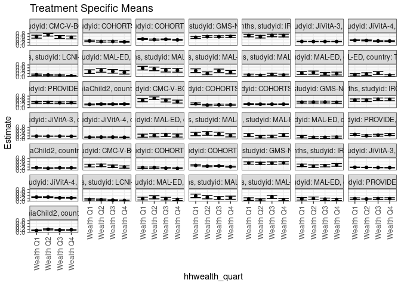

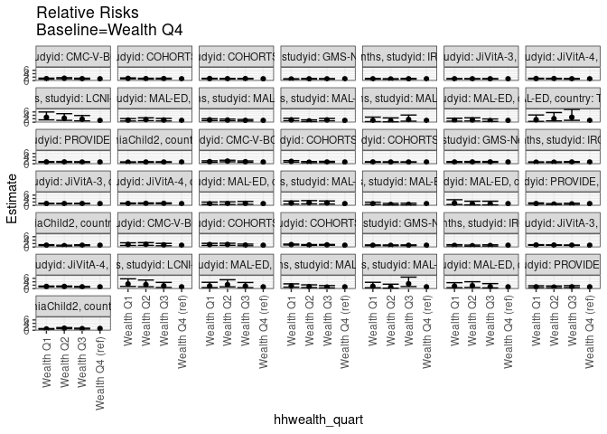

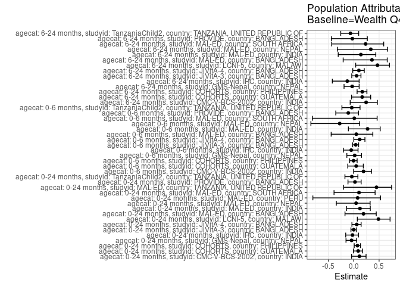

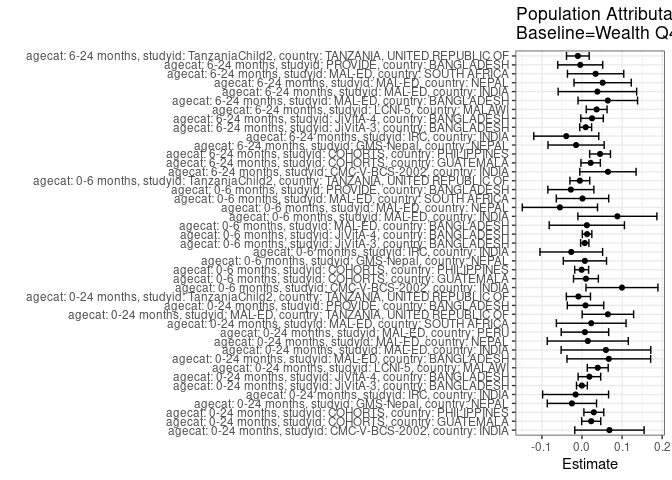

## Results Table

### Parameter: TSM

| agecat | studyid | country | intervention_level | baseline_level | estimate | ci_lower | ci_upper |
| --- | --- | --- | --- | --- | --- | --- | --- |
| 0-24 months | CMC-V-BCS-2002 | INDIA | Wealth Q4 | NA | 0.5427851 | 0.4418698 | 0.6437004 |
| 0-24 months | CMC-V-BCS-2002 | INDIA | Wealth Q1 | NA | 0.5967583 | 0.4934207 | 0.7000960 |
| 0-24 months | CMC-V-BCS-2002 | INDIA | Wealth Q2 | NA | 0.7277645 | 0.6388787 | 0.8166503 |
| 0-24 months | CMC-V-BCS-2002 | INDIA | Wealth Q3 | NA | 0.5746971 | 0.4739452 | 0.6754491 |
| 0-24 months | COHORTS | GUATEMALA | Wealth Q4 | NA | 0.2383083 | 0.2061027 | 0.2705139 |
| 0-24 months | COHORTS | GUATEMALA | Wealth Q1 | NA | 0.2991986 | 0.2488907 | 0.3495064 |
| 0-24 months | COHORTS | GUATEMALA | Wealth Q2 | NA | 0.2597802 | 0.2131826 | 0.3063777 |
| 0-24 months | COHORTS | GUATEMALA | Wealth Q3 | NA | 0.2648721 | 0.2198000 | 0.3099442 |
| 0-24 months | COHORTS | PHILIPPINES | Wealth Q4 | NA | 0.3741954 | 0.3447520 | 0.4036387 |
| 0-24 months | COHORTS | PHILIPPINES | Wealth Q1 | NA | 0.4351272 | 0.3995773 | 0.4706772 |
| 0-24 months | COHORTS | PHILIPPINES | Wealth Q2 | NA | 0.3931947 | 0.3537633 | 0.4326261 |
| 0-24 months | COHORTS | PHILIPPINES | Wealth Q3 | NA | 0.4126561 | 0.3836985 | 0.4416136 |
| 0-24 months | GMS-Nepal | NEPAL | Wealth Q4 | NA | 0.6155306 | 0.5432098 | 0.6878514 |
| 0-24 months | GMS-Nepal | NEPAL | Wealth Q1 | NA | 0.5498652 | 0.4822984 | 0.6174319 |
| 0-24 months | GMS-Nepal | NEPAL | Wealth Q2 | NA | 0.6000954 | 0.5311213 | 0.6690696 |
| 0-24 months | GMS-Nepal | NEPAL | Wealth Q3 | NA | 0.5935765 | 0.5241504 | 0.6630027 |
| 0-24 months | IRC | INDIA | Wealth Q4 | NA | 0.6720400 | 0.5775644 | 0.7665157 |
| 0-24 months | IRC | INDIA | Wealth Q1 | NA | 0.6723829 | 0.5835610 | 0.7612048 |
| 0-24 months | IRC | INDIA | Wealth Q2 | NA | 0.5984847 | 0.5040042 | 0.6929652 |
| 0-24 months | IRC | INDIA | Wealth Q3 | NA | 0.6789921 | 0.5890258 | 0.7689585 |
| 0-24 months | JiVitA-3 | BANGLADESH | Wealth Q4 | NA | 0.2581718 | 0.2430810 | 0.2732626 |
| 0-24 months | JiVitA-3 | BANGLADESH | Wealth Q1 | NA | 0.2631465 | 0.2497486 | 0.2765444 |
| 0-24 months | JiVitA-3 | BANGLADESH | Wealth Q2 | NA | 0.2588318 | 0.2463520 | 0.2713115 |
| 0-24 months | JiVitA-3 | BANGLADESH | Wealth Q3 | NA | 0.2597139 | 0.2475474 | 0.2718804 |
| 0-24 months | JiVitA-4 | BANGLADESH | Wealth Q4 | NA | 0.2916218 | 0.2615671 | 0.3216765 |
| 0-24 months | JiVitA-4 | BANGLADESH | Wealth Q1 | NA | 0.3434644 | 0.3150385 | 0.3718904 |
| 0-24 months | JiVitA-4 | BANGLADESH | Wealth Q2 | NA | 0.3324817 | 0.3005040 | 0.3644593 |
| 0-24 months | JiVitA-4 | BANGLADESH | Wealth Q3 | NA | 0.2936617 | 0.2641766 | 0.3231468 |
| 0-24 months | LCNI-5 | MALAWI | Wealth Q4 | NA | 0.0414747 | 0.0149300 | 0.0680193 |
| 0-24 months | LCNI-5 | MALAWI | Wealth Q1 | NA | 0.1176471 | 0.0734075 | 0.1618866 |

[output cut: 142 more lines]

### Parameter: E(Y)

| agecat | studyid | country | intervention_level | baseline_level | estimate | ci_lower | ci_upper |
| --- | --- | --- | --- | --- | --- | --- | --- |
| 0-24 months | CMC-V-BCS-2002 | INDIA | NA | NA | 0.6112601 | 0.5617242 | 0.6607959 |
| 0-24 months | COHORTS | GUATEMALA | NA | NA | 0.2612827 | 0.2370438 | 0.2855216 |
| 0-24 months | COHORTS | PHILIPPINES | NA | NA | 0.4037451 | 0.3863123 | 0.4211779 |
| 0-24 months | GMS-Nepal | NEPAL | NA | NA | 0.5903790 | 0.5535526 | 0.6272054 |
| 0-24 months | IRC | INDIA | NA | NA | 0.6560976 | 0.6100625 | 0.7021326 |
| 0-24 months | JiVitA-3 | BANGLADESH | NA | NA | 0.2579831 | 0.2515145 | 0.2644516 |
| 0-24 months | JiVitA-4 | BANGLADESH | NA | NA | 0.3101161 | 0.2957091 | 0.3245231 |
| 0-24 months | LCNI-5 | MALAWI | NA | NA | 0.0807834 | 0.0620863 | 0.0994804 |
| 0-24 months | MAL-ED | BANGLADESH | NA | NA | 0.3471074 | 0.2870050 | 0.4072099 |
| 0-24 months | MAL-ED | INDIA | NA | NA | 0.4851064 | 0.4210714 | 0.5491414 |
| 0-24 months | MAL-ED | NEPAL | NA | NA | 0.3093220 | 0.2502261 | 0.3684179 |
| 0-24 months | MAL-ED | PERU | NA | NA | 0.0955882 | 0.0605817 | 0.1305947 |
| 0-24 months | MAL-ED | SOUTH AFRICA | NA | NA | 0.2217899 | 0.1708981 | 0.2726816 |
| 0-24 months | MAL-ED | TANZANIA, UNITED REPUBLIC OF | NA | NA | 0.1440000 | 0.1003920 | 0.1876080 |
| 0-24 months | PROVIDE | BANGLADESH | NA | NA | 0.3514286 | 0.3160364 | 0.3868207 |
| 0-24 months | TanzaniaChild2 | TANZANIA, UNITED REPUBLIC OF | NA | NA | 0.2365772 | 0.2195142 | 0.2536402 |
| 0-6 months | CMC-V-BCS-2002 | INDIA | NA | NA | 0.5163043 | 0.4651769 | 0.5674318 |
| 0-6 months | COHORTS | GUATEMALA | NA | NA | 0.2029557 | 0.1782002 | 0.2277111 |
| 0-6 months | COHORTS | PHILIPPINES | NA | NA | 0.2356227 | 0.2205417 | 0.2507038 |
| 0-6 months | GMS-Nepal | NEPAL | NA | NA | 0.3760933 | 0.3398180 | 0.4123685 |
| 0-6 months | IRC | INDIA | NA | NA | 0.5439024 | 0.4956326 | 0.5921723 |
| 0-6 months | JiVitA-3 | BANGLADESH | NA | NA | 0.1761878 | 0.1705589 | 0.1818167 |
| 0-6 months | JiVitA-4 | BANGLADESH | NA | NA | 0.1078103 | 0.0979894 | 0.1176312 |
| 0-6 months | MAL-ED | BANGLADESH | NA | NA | 0.2355372 | 0.1819640 | 0.2891104 |
| 0-6 months | MAL-ED | INDIA | NA | NA | 0.3234043 | 0.2634696 | 0.3833389 |
| 0-6 months | MAL-ED | NEPAL | NA | NA | 0.1991525 | 0.1480924 | 0.2502127 |
| 0-6 months | MAL-ED | SOUTH AFRICA | NA | NA | 0.1089494 | 0.0707821 | 0.1471167 |
| 0-6 months | PROVIDE | BANGLADESH | NA | NA | 0.2585714 | 0.2261125 | 0.2910304 |
| 0-6 months | TanzaniaChild2 | TANZANIA, UNITED REPUBLIC OF | NA | NA | 0.1392617 | 0.1253610 | 0.1531625 |
| 6-24 months | CMC-V-BCS-2002 | INDIA | NA | NA | 0.2654155 | 0.2205451 | 0.3102860 |
| 6-24 months | COHORTS | GUATEMALA | NA | NA | 0.1291161 | 0.1097606 | 0.1484716 |
| 6-24 months | COHORTS | PHILIPPINES | NA | NA | 0.2666429 | 0.2502871 | 0.2829988 |
| 6-24 months | GMS-Nepal | NEPAL | NA | NA | 0.4728814 | 0.4325613 | 0.5132014 |
| 6-24 months | IRC | INDIA | NA | NA | 0.3097561 | 0.2649438 | 0.3545684 |
| 6-24 months | JiVitA-3 | BANGLADESH | NA | NA | 0.1638036 | 0.1576801 | 0.1699271 |
| 6-24 months | JiVitA-4 | BANGLADESH | NA | NA | 0.2472801 | 0.2337480 | 0.2608122 |
| 6-24 months | LCNI-5 | MALAWI | NA | NA | 0.0782609 | 0.0596958 | 0.0968259 |
| 6-24 months | MAL-ED | BANGLADESH | NA | NA | 0.1791667 | 0.1305478 | 0.2277856 |
| 6-24 months | MAL-ED | INDIA | NA | NA | 0.2723404 | 0.2153029 | 0.3293779 |
| 6-24 months | MAL-ED | NEPAL | NA | NA | 0.1531915 | 0.1070438 | 0.1993392 |
| 6-24 months | MAL-ED | SOUTH AFRICA | NA | NA | 0.1450980 | 0.1017849 | 0.1884112 |
| 6-24 months | PROVIDE | BANGLADESH | NA | NA | 0.1609756 | 0.1319065 | 0.1900447 |
| 6-24 months | TanzaniaChild2 | TANZANIA, UNITED REPUBLIC OF | NA | NA | 0.1606965 | 0.1446374 | 0.1767556 |

### Parameter: RR

| agecat | studyid | country | intervention_level | baseline_level | estimate | ci_lower | ci_upper |
| --- | --- | --- | --- | --- | --- | --- | --- |
| 0-24 months | CMC-V-BCS-2002 | INDIA | Wealth Q4 | Wealth Q4 | 1.0000000 | 1.0000000 | 1.0000000 |
| 0-24 months | CMC-V-BCS-2002 | INDIA | Wealth Q1 | Wealth Q4 | 1.0994376 | 0.8520322 | 1.4186823 |
| 0-24 months | CMC-V-BCS-2002 | INDIA | Wealth Q2 | Wealth Q4 | 1.3407967 | 1.0740931 | 1.6737244 |
| 0-24 months | CMC-V-BCS-2002 | INDIA | Wealth Q3 | Wealth Q4 | 1.0587931 | 0.8206407 | 1.3660580 |
| 0-24 months | COHORTS | GUATEMALA | Wealth Q4 | Wealth Q4 | 1.0000000 | 1.0000000 | 1.0000000 |
| 0-24 months | COHORTS | GUATEMALA | Wealth Q1 | Wealth Q4 | 1.2555105 | 1.0280664 | 1.5332731 |
| 0-24 months | COHORTS | GUATEMALA | Wealth Q2 | Wealth Q4 | 1.0901013 | 0.8848574 | 1.3429518 |
| 0-24 months | COHORTS | GUATEMALA | Wealth Q3 | Wealth Q4 | 1.1114684 | 0.9101093 | 1.3573776 |
| 0-24 months | COHORTS | PHILIPPINES | Wealth Q4 | Wealth Q4 | 1.0000000 | 1.0000000 | 1.0000000 |
| 0-24 months | COHORTS | PHILIPPINES | Wealth Q1 | Wealth Q4 | 1.1628344 | 1.0421598 | 1.2974822 |
| 0-24 months | COHORTS | PHILIPPINES | Wealth Q2 | Wealth Q4 | 1.0507739 | 0.9285078 | 1.1891399 |
| 0-24 months | COHORTS | PHILIPPINES | Wealth Q3 | Wealth Q4 | 1.1027824 | 0.9972198 | 1.2195195 |
| 0-24 months | GMS-Nepal | NEPAL | Wealth Q4 | Wealth Q4 | 1.0000000 | 1.0000000 | 1.0000000 |
| 0-24 months | GMS-Nepal | NEPAL | Wealth Q1 | Wealth Q4 | 0.8933190 | 0.7565027 | 1.0548790 |
| 0-24 months | GMS-Nepal | NEPAL | Wealth Q2 | Wealth Q4 | 0.9749238 | 0.8301134 | 1.1449960 |
| 0-24 months | GMS-Nepal | NEPAL | Wealth Q3 | Wealth Q4 | 0.9643331 | 0.8196376 | 1.1345726 |
| 0-24 months | IRC | INDIA | Wealth Q4 | Wealth Q4 | 1.0000000 | 1.0000000 | 1.0000000 |
| 0-24 months | IRC | INDIA | Wealth Q1 | Wealth Q4 | 1.0005102 | 0.8251673 | 1.2131125 |
| 0-24 months | IRC | INDIA | Wealth Q2 | Wealth Q4 | 0.8905493 | 0.7211903 | 1.0996792 |
| 0-24 months | IRC | INDIA | Wealth Q3 | Wealth Q4 | 1.0103448 | 0.8328265 | 1.2257014 |
| 0-24 months | JiVitA-3 | BANGLADESH | Wealth Q4 | Wealth Q4 | 1.0000000 | 1.0000000 | 1.0000000 |
| 0-24 months | JiVitA-3 | BANGLADESH | Wealth Q1 | Wealth Q4 | 1.0192692 | 0.9461576 | 1.0980304 |
| 0-24 months | JiVitA-3 | BANGLADESH | Wealth Q2 | Wealth Q4 | 1.0025565 | 0.9335286 | 1.0766885 |
| 0-24 months | JiVitA-3 | BANGLADESH | Wealth Q3 | Wealth Q4 | 1.0059733 | 0.9355814 | 1.0816613 |
| 0-24 months | JiVitA-4 | BANGLADESH | Wealth Q4 | Wealth Q4 | 1.0000000 | 1.0000000 | 1.0000000 |
| 0-24 months | JiVitA-4 | BANGLADESH | Wealth Q1 | Wealth Q4 | 1.1777735 | 1.0340886 | 1.3414232 |
| 0-24 months | JiVitA-4 | BANGLADESH | Wealth Q2 | Wealth Q4 | 1.1401125 | 0.9934581 | 1.3084159 |
| 0-24 months | JiVitA-4 | BANGLADESH | Wealth Q3 | Wealth Q4 | 1.0069950 | 0.8733348 | 1.1611113 |
| 0-24 months | LCNI-5 | MALAWI | Wealth Q4 | Wealth Q4 | 1.0000000 | 1.0000000 | 1.0000000 |
| 0-24 months | LCNI-5 | MALAWI | Wealth Q1 | Wealth Q4 | 2.8366013 | 1.3502532 | 5.9591095 |

[output cut: 142 more lines]

### Parameter: PAR

| agecat | studyid | country | intervention_level | baseline_level | estimate | ci_lower | ci_upper |
| --- | --- | --- | --- | --- | --- | --- | --- |
| 0-24 months | CMC-V-BCS-2002 | INDIA | Wealth Q4 | NA | 0.0684749 | -0.0180511 | 0.1550010 |
| 0-24 months | COHORTS | GUATEMALA | Wealth Q4 | NA | 0.0229744 | -0.0007898 | 0.0467385 |
| 0-24 months | COHORTS | PHILIPPINES | Wealth Q4 | NA | 0.0295497 | 0.0047603 | 0.0543391 |
| 0-24 months | GMS-Nepal | NEPAL | Wealth Q4 | NA | -0.0251516 | -0.0866354 | 0.0363322 |
| 0-24 months | IRC | INDIA | Wealth Q4 | NA | -0.0159425 | -0.0982110 | 0.0663261 |
| 0-24 months | JiVitA-3 | BANGLADESH | Wealth Q4 | NA | -0.0001887 | -0.0137339 | 0.0133565 |
| 0-24 months | JiVitA-4 | BANGLADESH | Wealth Q4 | NA | 0.0184943 | -0.0096034 | 0.0465920 |
| 0-24 months | LCNI-5 | MALAWI | Wealth Q4 | NA | 0.0393087 | 0.0132339 | 0.0653835 |
| 0-24 months | MAL-ED | BANGLADESH | Wealth Q4 | NA | 0.0668940 | -0.0375095 | 0.1712976 |
| 0-24 months | MAL-ED | INDIA | Wealth Q4 | NA | 0.0598150 | -0.0520551 | 0.1716851 |
| 0-24 months | MAL-ED | NEPAL | Wealth Q4 | NA | 0.0144265 | -0.0866662 | 0.1155192 |
| 0-24 months | MAL-ED | PERU | Wealth Q4 | NA | 0.0073529 | -0.0518605 | 0.0665664 |
| 0-24 months | MAL-ED | SOUTH AFRICA | Wealth Q4 | NA | 0.0230244 | -0.0639366 | 0.1099854 |
| 0-24 months | MAL-ED | TANZANIA, UNITED REPUBLIC OF | Wealth Q4 | NA | 0.0646349 | 0.0004450 | 0.1288248 |
| 0-24 months | PROVIDE | BANGLADESH | Wealth Q4 | NA | 0.0088258 | -0.0366114 | 0.0542631 |
| 0-24 months | TanzaniaChild2 | TANZANIA, UNITED REPUBLIC OF | Wealth Q4 | NA | -0.0089276 | -0.0390395 | 0.0211843 |
| 0-6 months | CMC-V-BCS-2002 | INDIA | Wealth Q4 | NA | 0.0996974 | 0.0099232 | 0.1894716 |
| 0-6 months | COHORTS | GUATEMALA | Wealth Q4 | NA | 0.0098341 | -0.0211674 | 0.0408356 |
| 0-6 months | COHORTS | PHILIPPINES | Wealth Q4 | NA | -0.0008595 | -0.0182313 | 0.0165124 |
| 0-6 months | GMS-Nepal | NEPAL | Wealth Q4 | NA | 0.0072930 | -0.0466222 | 0.0612081 |
| 0-6 months | IRC | INDIA | Wealth Q4 | NA | -0.0267385 | -0.1049561 | 0.0514792 |
| 0-6 months | JiVitA-3 | BANGLADESH | Wealth Q4 | NA | 0.0069279 | -0.0034722 | 0.0173281 |
| 0-6 months | JiVitA-4 | BANGLADESH | Wealth Q4 | NA | 0.0127149 | 0.0008619 | 0.0245679 |
| 0-6 months | MAL-ED | BANGLADESH | Wealth Q4 | NA | 0.0120554 | -0.0818177 | 0.1059285 |
| 0-6 months | MAL-ED | INDIA | Wealth Q4 | NA | 0.0883445 | -0.0101841 | 0.1868732 |
| 0-6 months | MAL-ED | NEPAL | Wealth Q4 | NA | -0.0550847 | -0.1489240 | 0.0387545 |
| 0-6 months | MAL-ED | SOUTH AFRICA | Wealth Q4 | NA | 0.0012571 | -0.0641197 | 0.0666339 |
| 0-6 months | PROVIDE | BANGLADESH | Wealth Q4 | NA | -0.0277448 | -0.0852101 | 0.0297205 |
| 0-6 months | TanzaniaChild2 | TANZANIA, UNITED REPUBLIC OF | Wealth Q4 | NA | -0.0053837 | -0.0301563 | 0.0193889 |
| 6-24 months | CMC-V-BCS-2002 | INDIA | Wealth Q4 | NA | 0.0647906 | -0.0054318 | 0.1350130 |
| 6-24 months | COHORTS | GUATEMALA | Wealth Q4 | NA | 0.0215490 | -0.0026706 | 0.0457687 |
| 6-24 months | COHORTS | PHILIPPINES | Wealth Q4 | NA | 0.0450575 | 0.0191314 | 0.0709836 |
| 6-24 months | GMS-Nepal | NEPAL | Wealth Q4 | NA | -0.0147417 | -0.0848671 | 0.0553837 |
| 6-24 months | IRC | INDIA | Wealth Q4 | NA | -0.0392352 | -0.1203409 | 0.0418704 |
| 6-24 months | JiVitA-3 | BANGLADESH | Wealth Q4 | NA | 0.0092474 | -0.0055741 | 0.0240689 |
| 6-24 months | JiVitA-4 | BANGLADESH | Wealth Q4 | NA | 0.0251125 | -0.0030251 | 0.0532502 |
| 6-24 months | LCNI-5 | MALAWI | Wealth Q4 | NA | 0.0365942 | 0.0106304 | 0.0625580 |
| 6-24 months | MAL-ED | BANGLADESH | Wealth Q4 | NA | 0.0644126 | -0.0098997 | 0.1387248 |
| 6-24 months | MAL-ED | INDIA | Wealth Q4 | NA | 0.0384739 | -0.0594856 | 0.1364333 |
| 6-24 months | MAL-ED | NEPAL | Wealth Q4 | NA | 0.0514966 | -0.0199428 | 0.1229360 |
| 6-24 months | MAL-ED | SOUTH AFRICA | Wealth Q4 | NA | 0.0339869 | -0.0362597 | 0.1042336 |
| 6-24 months | PROVIDE | BANGLADESH | Wealth Q4 | NA | -0.0043299 | -0.0603885 | 0.0517288 |
| 6-24 months | TanzaniaChild2 | TANZANIA, UNITED REPUBLIC OF | Wealth Q4 | NA | -0.0103334 | -0.0386327 | 0.0179658 |

### Parameter: PAF

| agecat | studyid | country | intervention_level | baseline_level | estimate | ci_lower | ci_upper |
| --- | --- | --- | --- | --- | --- | --- | --- |
| 0-24 months | CMC-V-BCS-2002 | INDIA | Wealth Q4 | NA | 0.1120226 | -0.0420805 | 0.2433369 |
| 0-24 months | COHORTS | GUATEMALA | Wealth Q4 | NA | 0.0879292 | -0.0072151 | 0.1740858 |
| 0-24 months | COHORTS | PHILIPPINES | Wealth Q4 | NA | 0.0731890 | 0.0098253 | 0.1324980 |
| 0-24 months | GMS-Nepal | NEPAL | Wealth Q4 | NA | -0.0426024 | -0.1521008 | 0.0564890 |
| 0-24 months | IRC | INDIA | Wealth Q4 | NA | -0.0242989 | -0.1576909 | 0.0937234 |
| 0-24 months | JiVitA-3 | BANGLADESH | Wealth Q4 | NA | -0.0007314 | -0.0546371 | 0.0504190 |
| 0-24 months | JiVitA-4 | BANGLADESH | Wealth Q4 | NA | 0.0596366 | -0.0351685 | 0.1457591 |
| 0-24 months | LCNI-5 | MALAWI | Wealth Q4 | NA | 0.4865941 | 0.0711724 | 0.7162168 |
| 0-24 months | MAL-ED | BANGLADESH | Wealth Q4 | NA | 0.1927186 | -0.1720512 | 0.4439635 |
| 0-24 months | MAL-ED | INDIA | Wealth Q4 | NA | 0.1233028 | -0.1411652 | 0.3264797 |
| 0-24 months | MAL-ED | NEPAL | Wealth Q4 | NA | 0.0466392 | -0.3430392 | 0.3232536 |
| 0-24 months | MAL-ED | PERU | Wealth Q4 | NA | 0.0769231 | -0.8048615 | 0.5279023 |
| 0-24 months | MAL-ED | SOUTH AFRICA | Wealth Q4 | NA | 0.1038116 | -0.3880070 | 0.4213620 |
| 0-24 months | MAL-ED | TANZANIA, UNITED REPUBLIC OF | Wealth Q4 | NA | 0.4488536 | -0.1993803 | 0.7467339 |
| 0-24 months | PROVIDE | BANGLADESH | Wealth Q4 | NA | 0.0251142 | -0.1131511 | 0.1462054 |
| 0-24 months | TanzaniaChild2 | TANZANIA, UNITED REPUBLIC OF | Wealth Q4 | NA | -0.0377366 | -0.1731646 | 0.0820578 |
| 0-6 months | CMC-V-BCS-2002 | INDIA | Wealth Q4 | NA | 0.1930981 | -0.0022090 | 0.3503445 |
| 0-6 months | COHORTS | GUATEMALA | Wealth Q4 | NA | 0.0484544 | -0.1171405 | 0.1895029 |
| 0-6 months | COHORTS | PHILIPPINES | Wealth Q4 | NA | -0.0036477 | -0.0801560 | 0.0674414 |
| 0-6 months | GMS-Nepal | NEPAL | Wealth Q4 | NA | 0.0193914 | -0.1350174 | 0.1527943 |
| 0-6 months | IRC | INDIA | Wealth Q4 | NA | -0.0491604 | -0.2033101 | 0.0852420 |
| 0-6 months | JiVitA-3 | BANGLADESH | Wealth Q4 | NA | 0.0393213 | -0.0215647 | 0.0965784 |
| 0-6 months | JiVitA-4 | BANGLADESH | Wealth Q4 | NA | 0.1179376 | 0.0015432 | 0.2207634 |
| 0-6 months | MAL-ED | BANGLADESH | Wealth Q4 | NA | 0.0511827 | -0.4443151 | 0.3766912 |
| 0-6 months | MAL-ED | INDIA | Wealth Q4 | NA | 0.2731706 | -0.1044731 | 0.5216897 |
| 0-6 months | MAL-ED | NEPAL | Wealth Q4 | NA | -0.2765957 | -0.8436894 | 0.1160677 |
| 0-6 months | MAL-ED | SOUTH AFRICA | Wealth Q4 | NA | 0.0115385 | -0.8138550 | 0.4613372 |
| 0-6 months | PROVIDE | BANGLADESH | Wealth Q4 | NA | -0.1073003 | -0.3533671 | 0.0940270 |
| 0-6 months | TanzaniaChild2 | TANZANIA, UNITED REPUBLIC OF | Wealth Q4 | NA | -0.0386591 | -0.2326323 | 0.1247896 |
| 6-24 months | CMC-V-BCS-2002 | INDIA | Wealth Q4 | NA | 0.2441100 | -0.0696848 | 0.4658524 |
| 6-24 months | COHORTS | GUATEMALA | Wealth Q4 | NA | 0.1668966 | -0.0420657 | 0.3339564 |
| 6-24 months | COHORTS | PHILIPPINES | Wealth Q4 | NA | 0.1689807 | 0.0665814 | 0.2601464 |
| 6-24 months | GMS-Nepal | NEPAL | Wealth Q4 | NA | -0.0311742 | -0.1906677 | 0.1069547 |
| 6-24 months | IRC | INDIA | Wealth Q4 | NA | -0.1266649 | -0.4213696 | 0.1069362 |
| 6-24 months | JiVitA-3 | BANGLADESH | Wealth Q4 | NA | 0.0564544 | -0.0385436 | 0.1427627 |
| 6-24 months | JiVitA-4 | BANGLADESH | Wealth Q4 | NA | 0.1015550 | -0.0192088 | 0.2080097 |
| 6-24 months | LCNI-5 | MALAWI | Wealth Q4 | NA | 0.4675926 | 0.0389644 | 0.7050498 |
| 6-24 months | MAL-ED | BANGLADESH | Wealth Q4 | NA | 0.3595120 | -0.2080619 | 0.6604273 |
| 6-24 months | MAL-ED | INDIA | Wealth Q4 | NA | 0.1412713 | -0.3054769 | 0.4351374 |
| 6-24 months | MAL-ED | NEPAL | Wealth Q4 | NA | 0.3361582 | -0.3232314 | 0.6669623 |
| 6-24 months | MAL-ED | SOUTH AFRICA | Wealth Q4 | NA | 0.2342342 | -0.4339632 | 0.5910654 |
| 6-24 months | PROVIDE | BANGLADESH | Wealth Q4 | NA | -0.0268977 | -0.4410415 | 0.2682245 |
| 6-24 months | TanzaniaChild2 | TANZANIA, UNITED REPUBLIC OF | Wealth Q4 | NA | -0.0643040 | -0.2558303 | 0.0980127 |